# Lab 03 - Parametric and Nonparametric Univariate Tests

Nonparametric statistics ay 2025/2026

2025-10-09

*Disclaimer: The present material has been slightly adapted from the original R script prepared by Prof. Cappozzo for the a.y. 2023-2024 Nonparametric statistics course. I hereby assume responsibility for any error that may be present in this document, I do apologise for them and invite you to let me know.*

```r
library(progress)
```

## Hands-On Comparison Between Parametric and Nonparametric Tests: some general ideas

My idea of this lecture is, alongside giving you some ideas on how to write some code to perform simulations (that may be useful for your projects and/or your thesis work), is to give you some hands on experience on why nonparametric tests are important, and what happens if you decide to use a parametric test when its assumptions are **not verified**.

Let’s start with an easy case: I want to test the equality of distributions. In other words, let $Y_1$ and $Y_2$ be two **independent random variables**, and the statistical hypothesis I want to test is $H_0: Y_1\stackrel{d}{=}Y_2$ vs $H_1: Y_1 \stackrel{d}{\neq} Y_2$.

Recall that, if $H_0$ is true, the Type-I error level ($\alpha$) is the **percentage of times I reject $H_0$ even if it is true**, if I keep as significance $\alpha$. This should be valid $\forall \alpha \in (0,1)$, although in practice we choose values such as $\alpha \in \{0.01, 0.05, 0.1\}$.

### Empirical assesment of Type-I (false positive) error

What I will be going to see is, in this context, the behavior of the empirical type-I error [^1] (i.e. the one that I measure in the practice) with respect to the nominal one. To do so, I will compute, using data sampled from different distributions, **the empirical probability distribution of the p-value of a t-test**, the test of choice in the case of normal distributions with equal variances, under $H_0$ (which, we know (and if we do not, we should…) that, if all the assumptions are respected, **should be distributed as a continuous uniform over the support $[0,1]$** ), and using it, I will compute the empirical type-I error.

So, let’s start with setting the scene a bit:

```r
alpha <- 0.05
n <- 10
B <- 5e4
seed <- 21071865
sigma <- 2
```

We will start by seeing the “healthy” case, namely a t-test on two samples of the same **normal** population with the same (unknown) variance

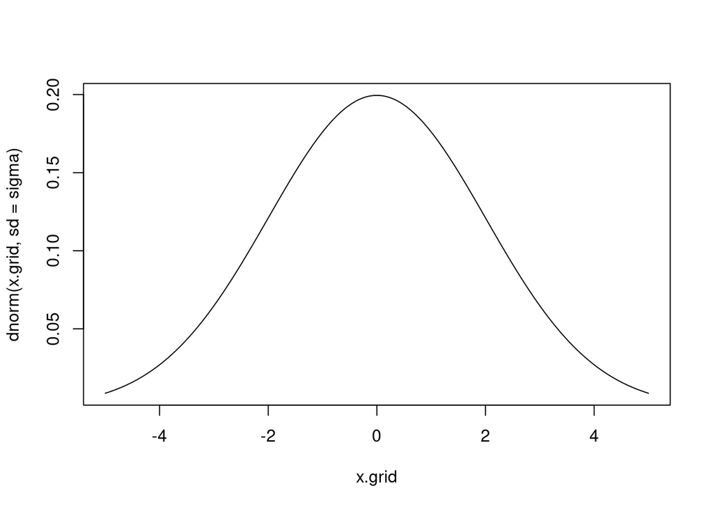

```r
x.grid <- seq(-5, 5, by=0.01)
plot(x.grid, dnorm(x.grid,sd=sigma), type='l')
```

Now, let’s directly estimate the distribution: I initialize my vector of values (so my cycle is faster), I use a progress bar (*so i don’t get frustrated*) and then I compute B times the p-value:

(you can actually see the progress bar if you run the instructions in the console)

```r
p.value <- numeric(B)
pb=progress_bar$new(total=B) # uncomment to use the progress bar
set.seed(seed)
pb$tick(0) # indicate the start of the loop
```

[output not shown]

```r
for(j in 1:B){
  # sample from the normal distribution
  x1 <- rnorm(n,sd=sigma)
  x2 <- rnorm(n,sd=sigma)
  p.value[j] <- t.test(x1,y=x2, paired=F)$p.value
  pb$tick() # tell the progress bar object one iteration is done
}
```

Let us see the empirical distribution, as well the empirical cumulative distribution function of the p-values in the simulation, compared to the one of a continuous uniform…

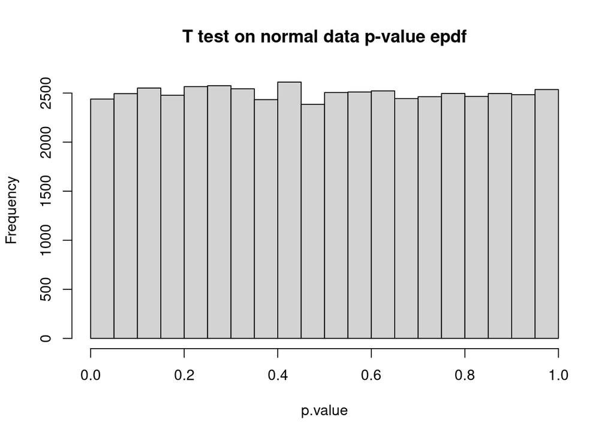

```r
hist(p.value, main = 'T test on normal data p-value epdf')
```

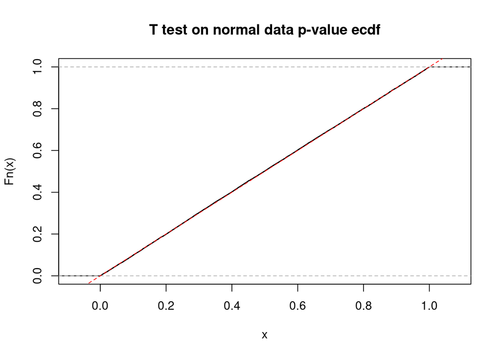

```r
plot(ecdf(p.value), main = 'T test on normal data p-value ecdf')
abline(0,1, lty=2, col='red')
```

As you can see (and as expected…) no issues here: the distribution of t-test p-values under $H_0$ with normal data is actually a uniform… The empirical type-I error of the test in this situation is indeed….

```r
estimated.alpha <- sum(p.value < alpha)/B
# produce a confidence interval for the estimated type-I error
c(lower=estimated.alpha - sqrt(estimated.alpha*(1-estimated.alpha)/B)*qnorm(0.975),
  estimate=estimated.alpha,
  upper=estimated.alpha + sqrt(estimated.alpha*(1-estimated.alpha)/B)*qnorm(0.975))
```

```
##     lower  estimate     upper
## 0.0468919 0.0487800 0.0506681
```